# STAT2401 Analysis of Experiments

Final Examination Semester 1 2024

Monday 10th June 2024

# STAT2401 Final Examination - Semester 1 2024 (60 marks)

## Student name: Himakar Gadham

## Student ID:23783777

# Instructions

1. You are provided with Rmd template for your working that you are strongly recommended to submit under Question 1 File Response for partial marks.
2. Save the RMD template (within the LMS, *right click ON the file, then Save Link As*) to your working directory and rename it in the format of *studentID_Surname.Rmd*, eg, *123456_Nur.Rmd*.
3. Marks for each question are shown. The total number of marks is 60.
   - This is a 2-hour examination.
   - You are provided with 15 minutes extra time for Rmarkdown template download, save and upload time.
   - There are 20 questions (Q2-Q21) set as multiple choice, multiple blanks, matching, calculated numeric. You must enter your answers on the LMS.
   - Include relevant R-output in your answers for some questions using R, if required.
     - You must provide your R code into the template provided here for full marks.
     - Incorrect answers with R code attempt will be allocated some partial marks.
     - If you have any question or comment about the exam or would like to alert your Unit Coordinator to a perceived error, include a comment in your working in Rmd file, if appropriate, to indicate how you interpreted the question.
   - Carry out all of your work in this Rmarkdown file.
4. **Save your work frequently!**
5. When you are finished, upload this *Rmarkdown file* back into *Question 1 File Response* on the LMS.
   - You only need to submit this RMD file.
   - You don’t need to knit this file.
   - DO NOT BE LATE. You must submit within the examination time (the last 15 minutes of 135 minutes).
   - **We do not accept any Rmd submission by email.**

## Remarks

- You can add your working in this file whenever applicable, eg theoretical question. Clearly indicates the question number before your answer.
- Make sure your program works for every chunk.
- It is your responsibility to call the libraries of R packages.
- The following chunk listed some R packages for the datasets that you may need to load as libraries.

```r
## R packages for the datasets
library(HSAUR2)
library(MASS)
library(ISLR)
```

# Based on Questions 2-21 on the LMS.

## Question 3

```r
library(MASS)
data(epil)
head(epil)
str(epil)
```

[output not shown]

```r
progabide_data <- subset(epil, trt == "progabide")

kendall_result <- cor.test(progabide_data$y, progabide_data$age, method = "kendall")

kendall_result
```

```
    Kendall's rank correlation tau

data:  progabide_data$y and progabide_data$age
z = -1.6167, p-value = 0.1059
alternative hypothesis: true tau is not equal to 0
sample estimates:
       tau
-0.1043932
```

```r
test_statistic <- kendall_result$statistic
test_statistic
```

```
        z
-1.616723
```

## Question 5

```r
Score<-c(4.58,4.36,4.19,4.57,4.39,4.52,4.37,4.55,4.62,4.65,4.63,4.52,4.43,4.71,4.73,4.76,4.52,4.71,4.52,4.64,4.86,4.66,4.65,4.84,5.02,4.78,4.65,4.81,4.96,4.79,5.02,4.84,4.62,4.84,5.00,5.11,5.08)
Years<-c(18,2,2,6,4,4,6,4,6,8,7,7,7,12,8,28,14,13,6,17,11,16,6,8,12,14,24,7,24,25,15,6,7,16,11,22,13)
Sales<-c(3.81,4.70,4.44,5.08,4.79,4.94,5.01,4.79,5.91,5.99,6.46,4.94,6.06,6.46,6.52,5.83,5.16,6.15,5.89,6.71,6.71,5.94,6.49,6.46,6.62,7.38,7.24,6.63,6.75,5.89,7.09,7.17,6.87,7.02,7.17,7.86,8.07)
Profit<-c(1.79,1.95,2.08,2.48,2.48,2.56,3.04,3.26,3.81,3.83,4.09,4.09,4.09,4.25,4.28,4.44,4.51,4.70,4.70,4.83,4.87,4.91,5.14,5.19,5.39,5.48,5.48,5.58,5.63,5.81,5.83,5.89,5.89,6.11,6.40,6.42,6.58)

credit.df=data.frame(Score,Years,Sales, Profit)
head(credit.df)
```

|  | Score | Years | Sales | Profit |
| --- | --- | --- | --- | --- |
| 1 | 4.58 | 18 | 3.81 | 1.79 |
| 2 | 4.36 | 2 | 4.70 | 1.95 |
| 3 | 4.19 | 2 | 4.44 | 2.08 |
| 4 | 4.57 | 6 | 5.08 | 2.48 |
| 5 | 4.39 | 4 | 4.79 | 2.48 |
| 6 | 4.52 | 4 | 4.94 | 2.56 |

```r
model <- lm(Score ~ Profit, data = credit.df)
summary(model)
```

```
Call:
lm(formula = Score ~ Profit, data = credit.df)

Residuals:
      Min        1Q    Median        3Q       Max
-0.244670 -0.087215 -0.000358  0.083358  0.246994

Coefficients:
            Estimate Std. Error t value Pr(>|t|)
(Intercept)  4.10089    0.07438   55.13  < 2e-16 ***
Profit       0.12967    0.01574    8.24 1.04e-09 ***
---
Signif. codes:  0 ‘***’ 0.001 ‘**’ 0.01 ‘*’ 0.05 ‘.’ 0.1 ‘ ’ 1

Residual standard error: 0.1268 on 35 degrees of freedom
Multiple R-squared:  0.6598,    Adjusted R-squared:  0.6501
F-statistic: 67.89 on 1 and 35 DF,  p-value: 1.037e-09
```

```r
r = 0.8123^2
r
```

```
[1] 0.6598313
```

## Question 6

```r
University<-c(1:33)
Year2008<-c(7018,7002,6926,6333,5432,5136,4994,4877,4726,4715,4405,4383,4335,4072,4047,3970,3872,3848,3819,3791,3761,3698,3575,3450,3204,3188,3132,2768,2725,2348,2256,3308,3374)
Year2014<-c(13706,13642,11738,11540,10690,8005,12106,10634,7386,6385,8231,8679,9300,9497,7656,8046,7750,8062,6435,7569,6802,8310,8532,6584,6544,7278,5524,5397,7042,5542,3256,6040,7844)
tuition.df <-data.frame(University,Year2008,Year2014)
head(tuition.df)
```

|  | University | Year2008 | Year2014 |
| --- | --- | --- | --- |
| 1 | 1 | 7018 | 13706 |
| 2 | 2 | 7002 | 13642 |
| 3 | 3 | 6926 | 11738 |
| 4 | 4 | 6333 | 11540 |
| 5 | 5 | 5432 | 10690 |
| 6 | 6 | 5136 | 8005 |

```r
model <- lm(Year2014 ~ Year2008, data = tuition.df)
summary(model)
```

```
Call:
lm(formula = Year2014 ~ Year2008, data = tuition.df)

Residuals:
     Min       1Q   Median       3Q      Max
-2727.22  -691.07    64.44   750.01  2521.62

Coefficients:
             Estimate Std. Error t value Pr(>|t|)
(Intercept) 1132.7501   701.4152   1.615    0.116
Year2008       1.6924     0.1604  10.552 8.75e-12 ***
---
Signif. codes:  0 ‘***’ 0.001 ‘**’ 0.01 ‘*’ 0.05 ‘.’ 0.1 ‘ ’ 1

Residual standard error: 1134 on 31 degrees of freedom
Multiple R-squared:  0.7822,    Adjusted R-squared:  0.7752
F-statistic: 111.3 on 1 and 31 DF,  p-value: 8.746e-12
```

```r
conf_interval <- confint(model, level = 0.99)
conf_interval
```

```
                  0.5 %      99.5 %
(Intercept) -791.962670 3057.462849
Year2008       1.252261    2.132454
```

```r
prediction_interval <- predict(model, newdata = data.frame(Year2008 = 5500), interval = "prediction", level = 0.90)
prediction_interval
```

```
       fit      lwr      upr
1 10440.72 8457.119 12424.32
```

## Question 8

```r
Score<-c(4.58,4.36,4.19,4.57,4.39,4.52,4.37,4.55,4.62,4.65,4.63,4.52,4.43,4.71,4.73,4.76,4.52,4.71,4.52,4.64,4.86,4.66,4.65,4.84,5.02,4.78,4.65,4.81,4.96,4.79,5.02,4.84,4.62,4.84,5.00,5.11,5.08)
Years<-c(18,2,2,6,4,4,6,4,6,8,7,7,7,12,8,28,14,13,6,17,11,16,6,8,12,14,24,7,24,25,15,6,7,16,11,22,13)
Sales<-c(3.81,4.70,4.44,5.08,4.79,4.94,5.01,4.79,5.91,5.99,6.46,4.94,6.06,6.46,6.52,5.83,5.16,6.15,5.89,6.71,6.71,5.94,6.49,6.46,6.62,7.38,7.24,6.63,6.75,5.89,7.09,7.17,6.87,7.02,7.17,7.86,8.07)
Profit<-c(1.79,1.95,2.08,2.48,2.48,2.56,3.04,3.26,3.81,3.83,4.09,4.09,4.09,4.25,4.28,4.44,4.51,4.70,4.70,4.83,4.87,4.91,5.14,5.19,5.39,5.48,5.48,5.58,5.63,5.81,5.83,5.89,5.89,6.11,6.40,6.42,6.58)

credit.df=data.frame(Score,Years,Sales, Profit)
head(credit.df)
```

|  | Score | Years | Sales | Profit |
| --- | --- | --- | --- | --- |
| 1 | 4.58 | 18 | 3.81 | 1.79 |
| 2 | 4.36 | 2 | 4.70 | 1.95 |
| 3 | 4.19 | 2 | 4.44 | 2.08 |
| 4 | 4.57 | 6 | 5.08 | 2.48 |
| 5 | 4.39 | 4 | 4.79 | 2.48 |
| 6 | 4.52 | 4 | 4.94 | 2.56 |

```r
model1 <- lm(Score ~ Sales, data = credit.df)
summary(model1)
```

```
Call:
lm(formula = Score ~ Sales, data = credit.df)

Residuals:
      Min        1Q    Median        3Q       Max
-0.246447 -0.099369  0.000752  0.088924  0.285116

Coefficients:
            Estimate Std. Error t value Pr(>|t|)
(Intercept)  3.64877    0.13539  26.950  < 2e-16 ***
Sales        0.16958    0.02178   7.785 3.82e-09 ***
---
Signif. codes:  0 ‘***’ 0.001 ‘**’ 0.01 ‘*’ 0.05 ‘.’ 0.1 ‘ ’ 1

Residual standard error: 0.1315 on 35 degrees of freedom
Multiple R-squared:  0.6339,    Adjusted R-squared:  0.6234
F-statistic:  60.6 on 1 and 35 DF,  p-value: 3.824e-09
```

```r
anova(model1)
```

```
Analysis of Variance Table

Response: Score
          Df  Sum Sq Mean Sq F value    Pr(>F)
Sales      1 1.04824  1.0482  60.599 3.824e-09 ***
Residuals 35 0.60543  0.0173
---
Signif. codes:  0 ‘***’ 0.001 ‘**’ 0.01 ‘*’ 0.05 ‘.’ 0.1 ‘ ’ 1
```

## Question 9

```r
Score<-c(4.58,4.36,4.19,4.57,4.39,4.52,4.37,4.55,4.62,4.65,4.63,4.52,4.43,4.71,4.73,4.76,4.52,4.71,4.52,4.64,4.86,4.66,4.65,4.84,5.02,4.78,4.65,4.81,4.96,4.79,5.02,4.84,4.62,4.84,5.00,5.11,5.08)
Years<-c(18,2,2,6,4,4,6,4,6,8,7,7,7,12,8,28,14,13,6,17,11,16,6,8,12,14,24,7,24,25,15,6,7,16,11,22,13)
Sales<-c(3.81,4.70,4.44,5.08,4.79,4.94,5.01,4.79,5.91,5.99,6.46,4.94,6.06,6.46,6.52,5.83,5.16,6.15,5.89,6.71,6.71,5.94,6.49,6.46,6.62,7.38,7.24,6.63,6.75,5.89,7.09,7.17,6.87,7.02,7.17,7.86,8.07)
Profit<-c(1.79,1.95,2.08,2.48,2.48,2.56,3.04,3.26,3.81,3.83,4.09,4.09,4.09,4.25,4.28,4.44,4.51,4.70,4.70,4.83,4.87,4.91,5.14,5.19,5.39,5.48,5.48,5.58,5.63,5.81,5.83,5.89,5.89,6.11,6.40,6.42,6.58)

credit.df=data.frame(Score,Years,Sales, Profit)
head(credit.df)
```

|  | Score | Years | Sales | Profit |
| --- | --- | --- | --- | --- |
| 1 | 4.58 | 18 | 3.81 | 1.79 |
| 2 | 4.36 | 2 | 4.70 | 1.95 |
| 3 | 4.19 | 2 | 4.44 | 2.08 |
| 4 | 4.57 | 6 | 5.08 | 2.48 |
| 5 | 4.39 | 4 | 4.79 | 2.48 |
| 6 | 4.52 | 4 | 4.94 | 2.56 |

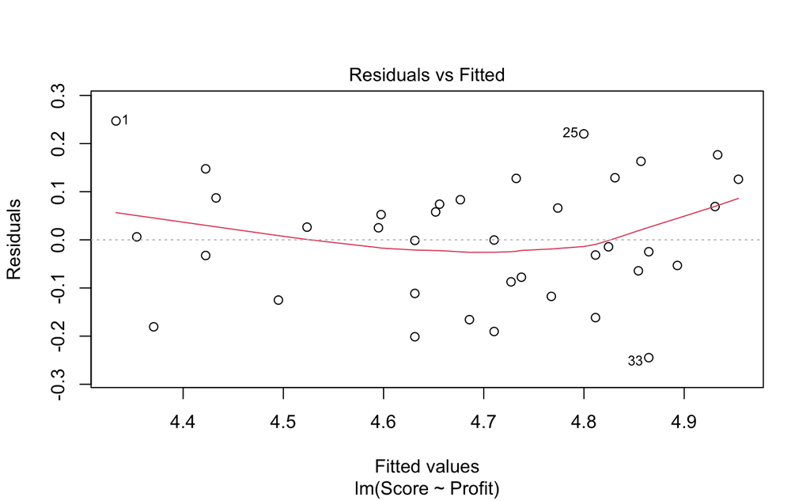

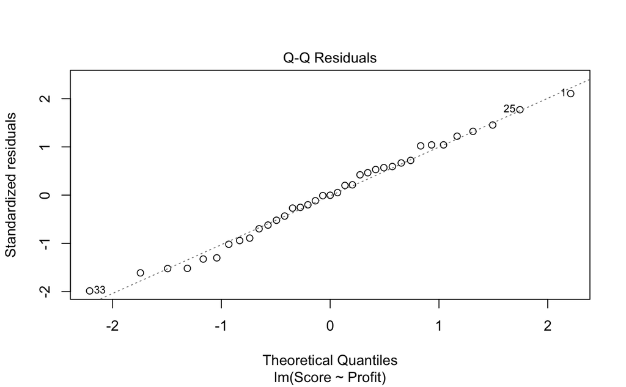

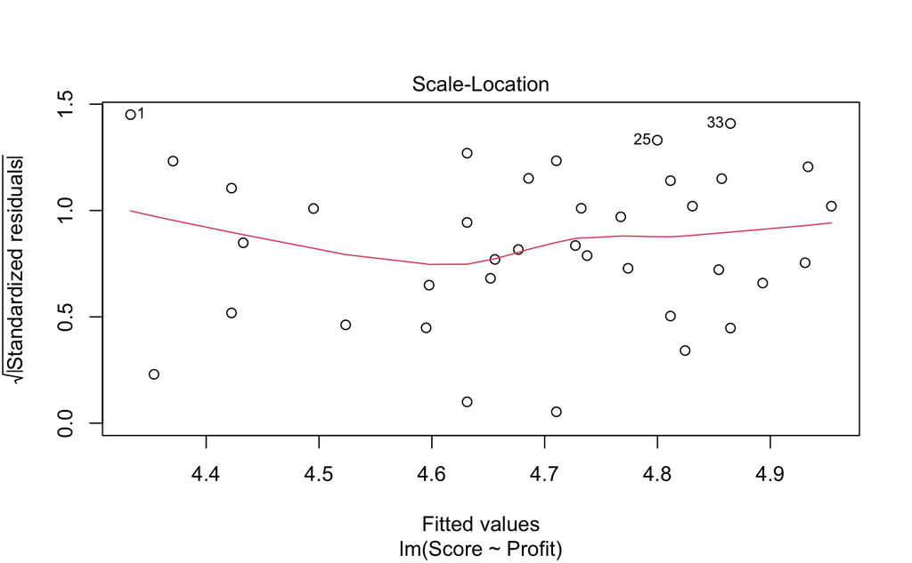

```r
model <- lm(Score ~ Profit, data = credit.df)
plot(model)
```

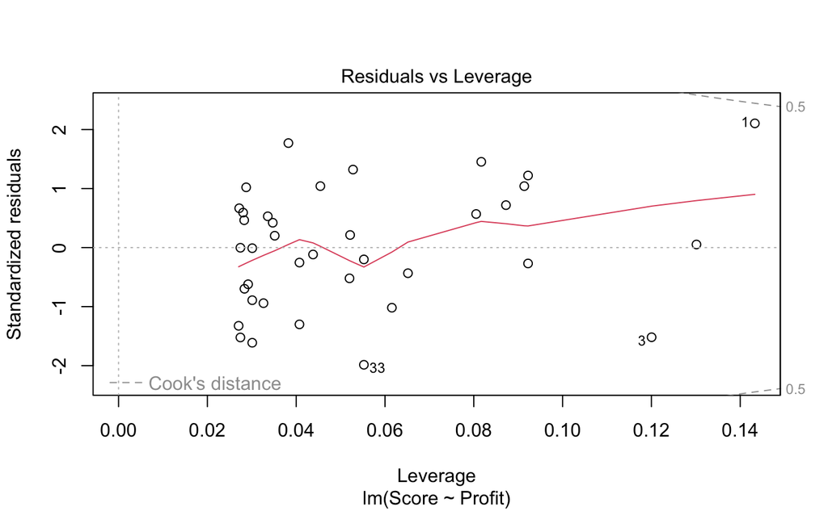

```r
NA
```

```r
leverage_values <- hatvalues(model)
n <- length(Score)
p <- 1
threshold <- 2 * (p + 1) / n
leverage_points <- which(leverage_values > threshold)
leverage_points
```

```
1 2 3
1 2 3
```

## Question 10

```r
Crews <-c(16,10,12,16,16,4,2,4,6,2,12,8,16,2,2,2,6,10,16,16,10,6,2,6,10,12,4,4,16,8,10,16,6,10,12,8,10,8,8,2,16,8,8,12,10,16,2,2,8,12,4,4,12)

Rooms <-c(51,37,37,46,45,11,6,19,29,14,47,37,60,6,11,10,19,33,46,69,41,19,6,27,35,55,15,18,72,22,55,65,26,52,55,33,38,23,38,10,65,31,33,47,42,78,6,6,40,39,9,22,41)
data <- data.frame(Crews, Rooms)

model_original <- lm(Rooms ~ Crews, data = data)
summary(model_original)
```

```
Call:
lm(formula = Rooms ~ Crews, data = data)

Residuals:
     Min       1Q   Median       3Q      Max
-15.9990  -4.9901   0.8046   4.0010  17.0010

Coefficients:
            Estimate Std. Error t value Pr(>|t|)
(Intercept)   1.7847     2.0965   0.851    0.399
Crews         3.7009     0.2118  17.472   <2e-16 ***
---
Signif. codes:  0 ‘***’ 0.001 ‘**’ 0.01 ‘*’ 0.05 ‘.’ 0.1 ‘ ’ 1

Residual standard error: 7.336 on 51 degrees of freedom
Multiple R-squared:  0.8569,    Adjusted R-squared:  0.854
F-statistic: 305.3 on 1 and 51 DF,  p-value: < 2.2e-16
```

```r
data$sqrt_Crews <- sqrt(data$Crews)
data$sqrt_Rooms <- sqrt(data$Rooms)

model_trans <- lm(sqrt_Rooms ~ sqrt_Crews, data = data)
summary(model_trans)
```

```
Call:
lm(formula = sqrt_Rooms ~ sqrt_Crews, data = data)

Residuals:
     Min       1Q   Median       3Q      Max
-1.09825 -0.43988  0.06826  0.42726  1.20275

Coefficients:
            Estimate Std. Error t value Pr(>|t|)
(Intercept)   0.2001     0.2757   0.726    0.471
sqrt_Crews    1.9016     0.0936  20.316   <2e-16 ***
---
Signif. codes:  0 ‘***’ 0.001 ‘**’ 0.01 ‘*’ 0.05 ‘.’ 0.1 ‘ ’ 1

Residual standard error: 0.594 on 51 degrees of freedom
Multiple R-squared:   0.89, Adjusted R-squared:  0.8879
F-statistic: 412.7 on 1 and 51 DF,  p-value: < 2.2e-16
```

```r
s <- model_trans$sigma
s
```

[output not shown]

```r
# Standard deviation of residuals for the transformed model
s_transformed <- sqrt(sum(residuals(model_trans)^2) / df.residual(model_trans))
cat("Standard deviation of residuals (s) for transformed data:", round(s_transformed, 3), "\n")
```

```
Standard deviation of residuals (s) for transformed data: 0.594
```

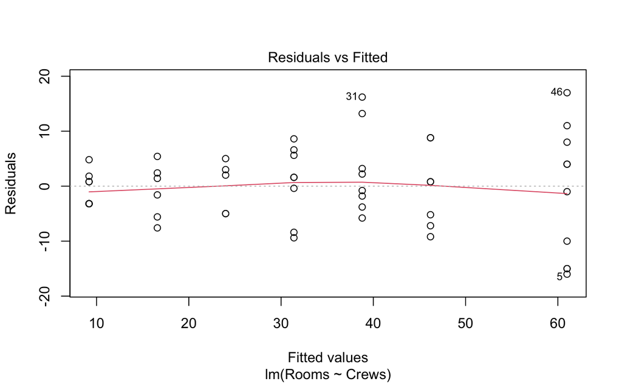

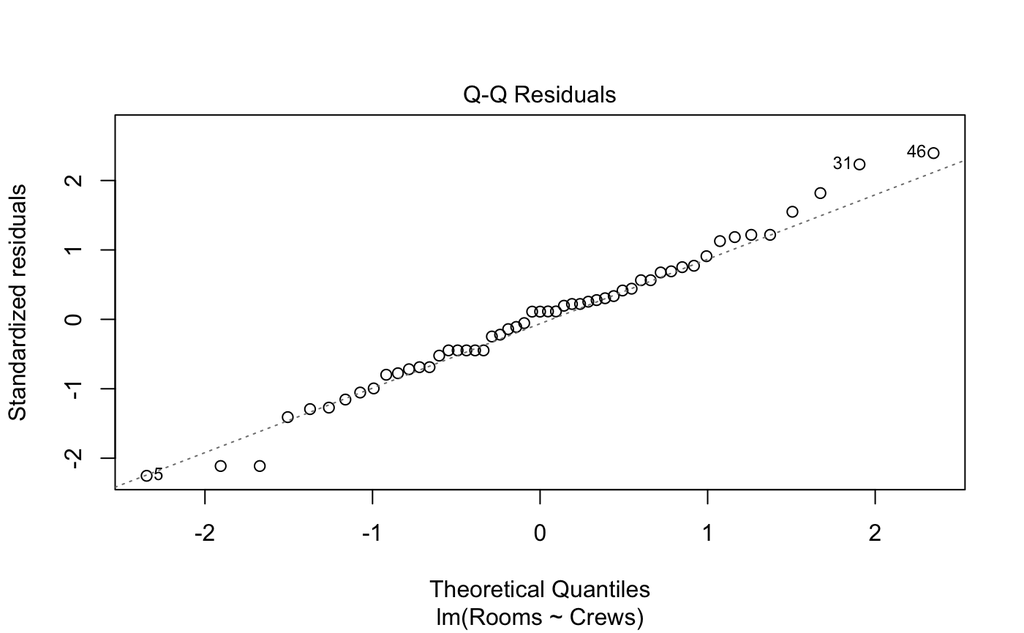

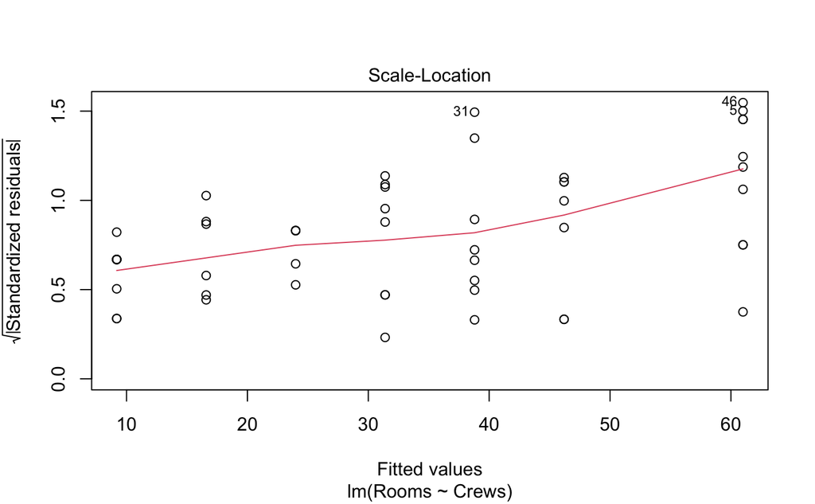

```r
plot(model_original)
```

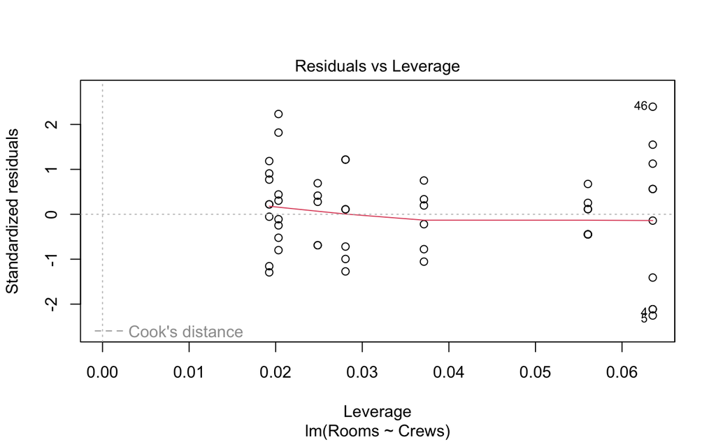

```r
NA
```

## Question 11

```r
data("airquality") # this data available in R base package, you don't need to install any R package
View(airquality) # to view the dataset

head(airquality) # to view the first 6 rows
```

|  | Ozone | Solar.R | Wind | Temp | Month | Day |
| --- | --- | --- | --- | --- | --- | --- |
| 1 | 41 | 190 | 7.4 | 67 | 5 | 1 |
| 2 | 36 | 118 | 8.0 | 72 | 5 | 2 |
| 3 | 12 | 149 | 12.6 | 74 | 5 | 3 |
| 4 | 18 | 313 | 11.5 | 62 | 5 | 4 |
| 5 | NA | NA | 14.3 | 56 | 5 | 5 |
| 6 | 28 | NA | 14.9 | 66 | 5 | 6 |

```r
m1 <- lm(Ozone ~ Solar.R + Wind + Temp, data = airquality)
summary(m1)
```

```
Call:
lm(formula = Ozone ~ Solar.R + Wind + Temp, data = airquality)

Residuals:
    Min      1Q  Median      3Q     Max
-40.485 -14.219  -3.551  10.097  95.619

Coefficients:
             Estimate Std. Error t value Pr(>|t|)
(Intercept) -64.34208   23.05472  -2.791  0.00623 **
Solar.R       0.05982    0.02319   2.580  0.01124 *
Wind         -3.33359    0.65441  -5.094 1.52e-06 ***
Temp          1.65209    0.25353   6.516 2.42e-09 ***
---
Signif. codes:  0 ‘***’ 0.001 ‘**’ 0.01 ‘*’ 0.05 ‘.’ 0.1 ‘ ’ 1

Residual standard error: 21.18 on 107 degrees of freedom
  (42 observations deleted due to missingness)
Multiple R-squared:  0.6059,    Adjusted R-squared:  0.5948
F-statistic: 54.83 on 3 and 107 DF,  p-value: < 2.2e-16
```

```r
anova_model <- anova(m1)
anova_model
```

```
Analysis of Variance Table

Response: Ozone
           Df Sum Sq Mean Sq F value    Pr(>F)
Solar.R     1  14780   14780  32.944 8.946e-08 ***
Wind        1  39969   39969  89.094 9.509e-16 ***
Temp        1  19050   19050  42.463 2.424e-09 ***
Residuals 107  48003     449
---
Signif. codes:  0 ‘***’ 0.001 ‘**’ 0.01 ‘*’ 0.05 ‘.’ 0.1 ‘ ’ 1
```

```r
f_value_wind <- anova_model["Wind", "F value"]
f_value_wind
```

```
[1] 89.0935
```

## Question 13

```r
library(HSAUR2)
attach(USairpollution)
pollution <- USairpollution
View(pollution) # 41 rows
head(pollution)
```

|  | SO2 | temp | manu | popul | wind | precip | predays |
| --- | --- | --- | --- | --- | --- | --- | --- |
| Albany | 46 | 47.6 | 44 | 116 | 8.8 | 33.36 | 135 |
| Albuquerque | 11 | 56.8 | 46 | 244 | 8.9 | 7.77 | 58 |
| Atlanta | 24 | 61.5 | 368 | 497 | 9.1 | 48.34 | 115 |
| Baltimore | 47 | 55.0 | 625 | 905 | 9.6 | 41.31 | 111 |
| Buffalo | 11 | 47.1 | 391 | 463 | 12.4 | 36.11 | 166 |
| Charleston | 31 | 55.2 | 35 | 71 | 6.5 | 40.75 | 148 |

```r
correlation_matrix <- cor(pollution[, -1])
correlation_matrix
```

```
               temp        manu       popul        wind      precip     predays
temp     1.00000000 -0.19004216 -0.06267813 -0.34973963  0.38625342 -0.43024212
manu    -0.19004216  1.00000000  0.95526935  0.23794683 -0.03241688  0.13182930
popul   -0.06267813  0.95526935  1.00000000  0.21264375 -0.02611873  0.04208319
wind    -0.34973963  0.23794683  0.21264375  1.00000000 -0.01299438  0.16410559
precip   0.38625342 -0.03241688 -0.02611873 -0.01299438  1.00000000  0.49609671
predays -0.43024212  0.13182930  0.04208319  0.16410559  0.49609671  1.00000000
```

```r
cor_max <- which(correlation_matrix == max(correlation_matrix[upper.tri(correlation_matrix)]), arr.ind = TRUE)
colnames(correlation_matrix)[cor_max]
```

```
[1] "popul" "manu"  "manu"  "popul"
```

```r
model <- lm(SO2 ~ temp + manu + popul + wind + precip + predays, data = pollution)
summary(model)
```

```
Call:
lm(formula = SO2 ~ temp + manu + popul + wind + precip + predays,
    data = pollution)

Residuals:
    Min      1Q  Median      3Q     Max
-23.004  -8.542  -0.991   5.758  48.758

Coefficients:
             Estimate Std. Error t value Pr(>|t|)
(Intercept) 111.72848   47.31810   2.361 0.024087 *
temp         -1.26794    0.62118  -2.041 0.049056 *
manu          0.06492    0.01575   4.122 0.000228 ***
popul        -0.03928    0.01513  -2.595 0.013846 *
wind         -3.18137    1.81502  -1.753 0.088650 .
precip        0.51236    0.36276   1.412 0.166918
predays      -0.05205    0.16201  -0.321 0.749972
---
Signif. codes:  0 ‘***’ 0.001 ‘**’ 0.01 ‘*’ 0.05 ‘.’ 0.1 ‘ ’ 1

Residual standard error: 14.64 on 34 degrees of freedom
Multiple R-squared:  0.6695,    Adjusted R-squared:  0.6112
F-statistic: 11.48 on 6 and 34 DF,  p-value: 5.419e-07
```

```r
coef_manu <- summary(model)$coefficients["manu", "Estimate"]
cat("Estimated regression coefficient for the variable 'manu':", round(coef_manu, 3), "\n")
```

```
Estimated regression coefficient for the variable 'manu': 0.065
```

```r
library(car)
vif_values <- vif(model)
vif_manu <- vif_values["manu"]
cat("VIF for the variable 'manu':", round(vif_manu, 3), "\n")
```

```
VIF for the variable 'manu': 14.704
```

## Question 14

```r
Score<-c(4.58,4.36,4.19,4.57,4.39,4.52,4.37,4.55,4.62,4.65,4.63,4.52,4.43,4.71,4.73,4.76,4.52,4.71,4.52,4.64,4.86,4.66,4.65,4.84,5.02,4.78,4.65,4.81,4.96,4.79,5.02,4.84,4.62,4.84,5.00,5.11,5.08)
Years<-c(18,2,2,6,4,4,6,4,6,8,7,7,7,12,8,28,14,13,6,17,11,16,6,8,12,14,24,7,24,25,15,6,7,16,11,22,13)
Sales<-c(3.81,4.70,4.44,5.08,4.79,4.94,5.01,4.79,5.91,5.99,6.46,4.94,6.06,6.46,6.52,5.83,5.16,6.15,5.89,6.71,6.71,5.94,6.49,6.46,6.62,7.38,7.24,6.63,6.75,5.89,7.09,7.17,6.87,7.02,7.17,7.86,8.07)
Profit<-c(1.79,1.95,2.08,2.48,2.48,2.56,3.04,3.26,3.81,3.83,4.09,4.09,4.09,4.25,4.28,4.44,4.51,4.70,4.70,4.83,4.87,4.91,5.14,5.19,5.39,5.48,5.48,5.58,5.63,5.81,5.83,5.89,5.89,6.11,6.40,6.42,6.58)

credit.df=data.frame(Score,Years,Sales, Profit)
head(credit.df)
```

|  | Score | Years | Sales | Profit |
| --- | --- | --- | --- | --- |
| 1 | 4.58 | 18 | 3.81 | 1.79 |
| 2 | 4.36 | 2 | 4.70 | 1.95 |
| 3 | 4.19 | 2 | 4.44 | 2.08 |
| 4 | 4.57 | 6 | 5.08 | 2.48 |
| 5 | 4.39 | 4 | 4.79 | 2.48 |
| 6 | 4.52 | 4 | 4.94 | 2.56 |

```r
model <- lm(Score ~ Years + Sales, data = credit.df)
summary(model)
```

```
Call:
lm(formula = Score ~ Years + Sales, data = credit.df)

Residuals:
      Min        1Q    Median        3Q       Max
-0.311295 -0.048004  0.008699  0.081765  0.252495

Coefficients:
            Estimate Std. Error t value Pr(>|t|)
(Intercept) 3.684083   0.125588  29.335  < 2e-16 ***
Years       0.008488   0.003178   2.671   0.0115 *
Sales       0.148272   0.021622   6.858 6.78e-08 ***
---
Signif. codes:  0 ‘***’ 0.001 ‘**’ 0.01 ‘*’ 0.05 ‘.’ 0.1 ‘ ’ 1

Residual standard error: 0.1213 on 34 degrees of freedom
Multiple R-squared:  0.6974,    Adjusted R-squared:  0.6796
F-statistic: 39.17 on 2 and 34 DF,  p-value: 1.498e-09
```

```r
n <- nrow(credit.df)
p <- 2
n
```

```
[1] 37
```

```r
p
```

```
[1] 2
```

```r
# Extract the estimates of beta
beta_hat <- coef(model)
cat("The elements of the vector beta_hat, the estimates of beta are:\n", round(beta_hat, 3), "\n")
```

```
The elements of the vector beta_hat, the estimates of beta are:
 3.684 0.008 0.148
```

```r
# Extract the covariance matrix of the coefficients
cov_matrix <- vcov(model)

# Sample covariance between beta_hat_1 and beta_hat_2
cov_beta1_beta2 <- cov_matrix["Years", "Sales"]
cat("The sample covariance between beta_hat_1 and beta_hat_2 is:", round(cov_beta1_beta2, 3), "\n")
```

```
The sample covariance between beta_hat_1 and beta_hat_2 is: 0
```

## Question 15

```r
library(MASS)
attach(Boston)
head(Boston) # to view the first 6 rows
```

|  | crim | zn | indus | chas | nox | rm | age | dis | rad | tax | ptratio | black | lstat | medv |
| --- | --- | --- | --- | --- | --- | --- | --- | --- | --- | --- | --- | --- | --- | --- |
| 1 | 0.00632 | 18 | 2.31 | 0 | 0.538 | 6.575 | 65.2 | 4.0900 | 1 | 296 | 15.3 | 396.90 | 4.98 | 24.0 |
| 2 | 0.02731 | 0 | 7.07 | 0 | 0.469 | 6.421 | 78.9 | 4.9671 | 2 | 242 | 17.8 | 396.90 | 9.14 | 21.6 |
| 3 | 0.02729 | 0 | 7.07 | 0 | 0.469 | 7.185 | 61.1 | 4.9671 | 2 | 242 | 17.8 | 392.83 | 4.03 | 34.7 |
| 4 | 0.03237 | 0 | 2.18 | 0 | 0.458 | 6.998 | 45.8 | 6.0622 | 3 | 222 | 18.7 | 394.63 | 2.94 | 33.4 |
| 5 | 0.06905 | 0 | 2.18 | 0 | 0.458 | 7.147 | 54.2 | 6.0622 | 3 | 222 | 18.7 | 396.90 | 5.33 | 36.2 |
| 6 | 0.02985 | 0 | 2.18 | 0 | 0.458 | 6.430 | 58.7 | 6.0622 | 3 | 222 | 18.7 | 394.12 | 5.21 | 28.7 |

```r
model_reduced <- lm(medv ~ lstat + rm + ptratio, data = Boston)
model_full <- lm(medv ~ lstat + rm + ptratio + dis + nox + chas + black, data = Boston)
anova(model_reduced, model_full)
```

```
Analysis of Variance Table

Model 1: medv ~ lstat + rm + ptratio
Model 2: medv ~ lstat + rm + ptratio + dis + nox + chas + black
  Res.Df   RSS Df Sum of Sq      F    Pr(>F)
1    502 13728
2    498 11868  4    1859.8 19.509 6.292e-15 ***
---
Signif. codes:  0 ‘***’ 0.001 ‘**’ 0.01 ‘*’ 0.05 ‘.’ 0.1 ‘ ’ 1
```

## Question 16

```r
library(ISLR)

attach(Carseats)
#head(Carseats) # to view the first 6 rows

full <- regsubsets(Sales ~ ., data = Carseats, nvmax = 11)
AllSubsets.summary <- summary(full)
AllSubsets.summary
```

```
Subset selection object
Call: regsubsets.formula(Sales ~ ., data = Carseats, nvmax = 11)
11 Variables  (and intercept)
                Forced in Forced out
CompPrice           FALSE      FALSE
Income              FALSE      FALSE
Advertising         FALSE      FALSE
Population          FALSE      FALSE
Price               FALSE      FALSE
ShelveLocGood       FALSE      FALSE
ShelveLocMedium     FALSE      FALSE
Age                 FALSE      FALSE
Education           FALSE      FALSE
UrbanYes            FALSE      FALSE
USYes               FALSE      FALSE
1 subsets of each size up to 11
Selection Algorithm: exhaustive
          CompPrice Income Advertising Population Price ShelveLocGood ShelveLocMedium Age Education UrbanYes USYes
1  ( 1 )  " "       " "    " "         " "        " "   "*"           " "             " " " "       " "      " "
2  ( 1 )  " "       " "    " "         " "        "*"   "*"           " "             " " " "       " "      " "
3  ( 1 )  "*"       " "    " "         " "        "*"   "*"           " "             " " " "       " "      " "
4  ( 1 )  "*"       " "    "*"         " "        "*"   "*"           " "             " " " "       " "      " "
5  ( 1 )  "*"       " "    "*"         " "        "*"   "*"           "*"             " " " "       " "      " "
6  ( 1 )  "*"       " "    "*"         " "        "*"   "*"           "*"             "*" " "       " "      " "
7  ( 1 )  "*"       "*"    "*"         " "        "*"   "*"           "*"             "*" " "       " "      " "
8  ( 1 )  "*"       "*"    "*"         " "        "*"   "*"           "*"             "*" " "       " "      "*"
9  ( 1 )  "*"       "*"    "*"         " "        "*"   "*"           "*"             "*" "*"       " "      "*"
10  ( 1 ) "*"       "*"    "*"         " "        "*"   "*"           "*"             "*" "*"       "*"      "*"
11  ( 1 ) "*"       "*"    "*"         "*"        "*"   "*"           "*"             "*" "*"       "*"      "*"
```

```r
modelf <- lm(Sales ~ CompPrice+Advertising + Price + ShelveLoc, data = Carseats)
summary(modelf)
```

```
Call:
lm(formula = Sales ~ CompPrice + Advertising + Price + ShelveLoc,
    data = Carseats)

Residuals:
    Min      1Q  Median      3Q     Max
-3.7623 -0.8846  0.0415  0.9146  4.4649

Coefficients:
                 Estimate Std. Error t value Pr(>|t|)
(Intercept)      3.844428   0.564487    6.81 3.65e-11 ***
CompPrice        0.093744   0.005398   17.37  < 2e-16 ***
Advertising      0.120280   0.010121   11.88  < 2e-16 ***
Price           -0.093592   0.003500  -26.74  < 2e-16 ***
ShelveLocGood    4.729319   0.199910   23.66  < 2e-16 ***
ShelveLocMedium  1.772761   0.163926   10.81  < 2e-16 ***
---
Signif. codes:  0 ‘***’ 0.001 ‘**’ 0.01 ‘*’ 0.05 ‘.’ 0.1 ‘ ’ 1

Residual standard error: 1.338 on 394 degrees of freedom
Multiple R-squared:  0.7782,    Adjusted R-squared:  0.7754
F-statistic: 276.5 on 5 and 394 DF,  p-value: < 2.2e-16
```

```r
final_model_formula <- as.formula(paste("Sales ~", paste(best_bic_vars[-1], collapse = "+")))
```

```
Error: object 'best_bic_vars' not found
```

```r
# Modify some graphical parameters
par(mfrow = c(1, 3))
par(cex.axis = 1.5)
par(cex.lab = 1.5)

plot(1:11, AllSubsets.summary$adjr2, xlab = "subset size", ylab = "adjusted R-squared",
    type = "b")
plot(1:11, AllSubsets.summary$cp, xlab = "subset size", ylab = "Mallows' Cp", type = "b")
```

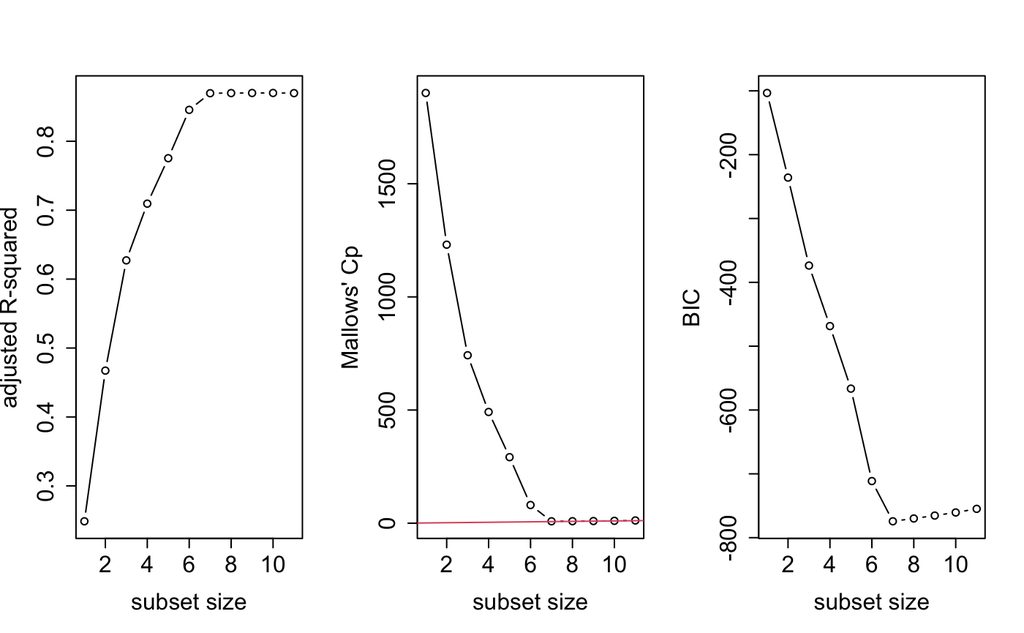

```r
abline(0, 1, col = 2)
plot(1:11, AllSubsets.summary$bic, xlab = "subset size", ylab = "BIC", type = "b")
```

```r
adj_r2_7_vars <-AllSubsets.summary$adjr2[7]
cat("The value of the adjusted R squared for the subset size equals 7 is:", round(adj_r2_7_vars, 3), "\n")
```

```
The value of the adjusted R squared for the subset size equals 7 is: 0.87
```

## Question 17

```r
library(ISLR)

attach(Carseats)
#head(Carseats) # to view the first 6 rows

full_model <- lm(Sales ~ ., data = Carseats)
summary(full_model)
```

```
Call:
lm(formula = Sales ~ ., data = Carseats)

Residuals:
    Min      1Q  Median      3Q     Max
-2.8692 -0.6908  0.0211  0.6636  3.4115

Coefficients:
                  Estimate Std. Error t value Pr(>|t|)
(Intercept)      5.6606231  0.6034487   9.380  < 2e-16 ***
CompPrice        0.0928153  0.0041477  22.378  < 2e-16 ***
Income           0.0158028  0.0018451   8.565 2.58e-16 ***
Advertising      0.1230951  0.0111237  11.066  < 2e-16 ***
Population       0.0002079  0.0003705   0.561    0.575
Price           -0.0953579  0.0026711 -35.700  < 2e-16 ***
ShelveLocGood    4.8501827  0.1531100  31.678  < 2e-16 ***
ShelveLocMedium  1.9567148  0.1261056  15.516  < 2e-16 ***
Age             -0.0460452  0.0031817 -14.472  < 2e-16 ***
Education       -0.0211018  0.0197205  -1.070    0.285
UrbanYes         0.1228864  0.1129761   1.088    0.277
USYes           -0.1840928  0.1498423  -1.229    0.220
---
Signif. codes:  0 ‘***’ 0.001 ‘**’ 0.01 ‘*’ 0.05 ‘.’ 0.1 ‘ ’ 1

Residual standard error: 1.019 on 388 degrees of freedom
Multiple R-squared:  0.8734,    Adjusted R-squared:  0.8698
F-statistic: 243.4 on 11 and 388 DF,  p-value: < 2.2e-16
```

```r
AIC(full_model)
```

```
[1] 1163.974
```

```r
backward_model <- step(full_model, direction = "backward", trace = 0)
summary_backward_model <- summary(backward_model)
summary_backward_model
```

```
Call:
lm(formula = Sales ~ CompPrice + Income + Advertising + Price +
    ShelveLoc + Age, data = Carseats)

Residuals:
    Min      1Q  Median      3Q     Max
-2.7728 -0.6954  0.0282  0.6732  3.3292

Coefficients:
                 Estimate Std. Error t value Pr(>|t|)
(Intercept)      5.475226   0.505005   10.84   <2e-16 ***
CompPrice        0.092571   0.004123   22.45   <2e-16 ***
Income           0.015785   0.001838    8.59   <2e-16 ***
Advertising      0.115903   0.007724   15.01   <2e-16 ***
Price           -0.095319   0.002670  -35.70   <2e-16 ***
ShelveLocGood    4.835675   0.152499   31.71   <2e-16 ***
ShelveLocMedium  1.951993   0.125375   15.57   <2e-16 ***
Age             -0.046128   0.003177  -14.52   <2e-16 ***
---
Signif. codes:  0 ‘***’ 0.001 ‘**’ 0.01 ‘*’ 0.05 ‘.’ 0.1 ‘ ’ 1

Residual standard error: 1.019 on 392 degrees of freedom
Multiple R-squared:  0.872, Adjusted R-squared:  0.8697
F-statistic: 381.4 on 7 and 392 DF,  p-value: < 2.2e-16
```

```r
sigma <- summary_backward_model$sigma
sigma
```

```
[1] 1.019437
```

```r
coefficients <- summary_backward_model$coefficients
coef <- coefficients["ShelveLocMedium", "Estimate"]
coef
```

```
[1] 1.951993
```

## Question 18

```r
library(ISLR)

data(College)
head(College)
str(College)

null_model <- lm(Apps ~ 1, data = College)
full_model <- lm(Apps ~ ., data = College)
```

[output not shown]

```r
forward_model <- step(null_model, scope = list(lower = null_model, upper = full_model), direction = "forward", trace = 0)
summary_forward_model <- summary(forward_model)
summary_forward_model
r_squared <- summary_forward_model$r.squared
r_squared
```

[output not shown]

## Question 19

```r
library(ISLR)

attach(Carseats)
head(Carseats) # to view the first 6 rows
```

|  | Sales | CompPrice | Income | Advertising | Population | Price | ShelveLoc | Age | Education | Urban | US |
| --- | --- | --- | --- | --- | --- | --- | --- | --- | --- | --- | --- |
| 1 | 9.50 | 138 | 73 | 11 | 276 | 120 | Bad | 42 | 17 | Yes | Yes |
| 2 | 11.22 | 111 | 48 | 16 | 260 | 83 | Good | 65 | 10 | Yes | Yes |
| 3 | 10.06 | 113 | 35 | 10 | 269 | 80 | Medium | 59 | 12 | Yes | Yes |
| 4 | 7.40 | 117 | 100 | 4 | 466 | 97 | Medium | 55 | 14 | Yes | Yes |
| 5 | 4.15 | 141 | 64 | 3 | 340 | 128 | Bad | 38 | 13 | Yes | No |
| 6 | 10.81 | 124 | 113 | 13 | 501 | 72 | Bad | 78 | 16 | No | Yes |

```r
null_model <- lm(Sales ~ 1, data = Carseats)
full_model <- lm(Sales ~ ., data = Carseats)

forward_model <- step(null_model, scope = list(lower = null_model, upper = full_model), direction = "forward")
```

```
Start:  AIC=831.55
Sales ~ 1

              Df Sum of Sq    RSS    AIC
+ ShelveLoc    2   1009.53 2172.7 682.91
+ Price        1    630.03 2552.2 745.31
+ Advertising  1    231.14 2951.1 803.39
+ Age          1    171.01 3011.3 811.46
+ US           1     99.80 3082.5 820.81
+ Income       1     73.48 3108.8 824.21
<none>                     3182.3 831.55
+ CompPrice    1     13.07 3169.2 831.91
+ Education    1      8.59 3173.7 832.47
+ Population   1      8.11 3174.2 832.53
+ Urban        1      0.76 3181.5 833.46

Step:  AIC=682.91
Sales ~ ShelveLoc

              Df Sum of Sq    RSS    AIC
+ Price        1    717.10 1455.6 524.69
+ Advertising  1    178.35 1994.4 650.65
+ Age          1    175.00 1997.8 651.32
+ Income       1     99.93 2072.8 666.08
+ US           1     66.54 2106.2 672.47
<none>                     2172.7 682.91
+ Population   1     10.71 2162.0 682.94
+ CompPrice    1      6.00 2166.7 683.81
+ Education    1      4.19 2168.6 684.14
+ Urban        1      1.70 2171.1 684.60

Step:  AIC=524.69
Sales ~ ShelveLoc + Price

              Df Sum of Sq     RSS    AIC
+ CompPrice    1    496.96  958.68 359.64
+ Age          1    258.05 1197.59 448.64
+ Advertising  1    209.73 1245.91 464.46
+ US           1     93.07 1362.57 500.26
+ Income       1     73.04 1382.60 506.10
```

[output cut: 35 more lines]

```
+ Education   1     2.488 481.58 90.243
<none>                    484.07 90.304
+ Urban       1     1.975 482.09 90.669
+ US          1     0.443 483.62 91.937
+ Population  1     0.285 483.78 92.069

Step:  AIC=23.32
Sales ~ ShelveLoc + Price + CompPrice + Advertising + Age + Income

             Df Sum of Sq    RSS    AIC
<none>                    407.39 23.320
+ US          1   1.62857 405.76 23.717
+ Education   1   1.22240 406.16 24.117
+ Urban       1   1.18994 406.20 24.149
+ Population  1   0.71569 406.67 24.616
```

```r
summary_forward_model <- summary(forward_model)
summary_forward_model
```

```
Call:
lm(formula = Sales ~ ShelveLoc + Price + CompPrice + Advertising +
    Age + Income, data = Carseats)

Residuals:
    Min      1Q  Median      3Q     Max
-2.7728 -0.6954  0.0282  0.6732  3.3292

Coefficients:
                 Estimate Std. Error t value Pr(>|t|)
(Intercept)      5.475226   0.505005   10.84   <2e-16 ***
ShelveLocGood    4.835675   0.152499   31.71   <2e-16 ***
ShelveLocMedium  1.951993   0.125375   15.57   <2e-16 ***
Price           -0.095319   0.002670  -35.70   <2e-16 ***
CompPrice        0.092571   0.004123   22.45   <2e-16 ***
Advertising      0.115903   0.007724   15.01   <2e-16 ***
Age             -0.046128   0.003177  -14.52   <2e-16 ***
Income           0.015785   0.001838    8.59   <2e-16 ***
---
Signif. codes:  0 ‘***’ 0.001 ‘**’ 0.01 ‘*’ 0.05 ‘.’ 0.1 ‘ ’ 1

Residual standard error: 1.019 on 392 degrees of freedom
Multiple R-squared:  0.872, Adjusted R-squared:  0.8697
F-statistic: 381.4 on 7 and 392 DF,  p-value: < 2.2e-16
```

```r
library(DAAG)
press(forward_model)
```

```
[1] 424.1901
```

## Question 20

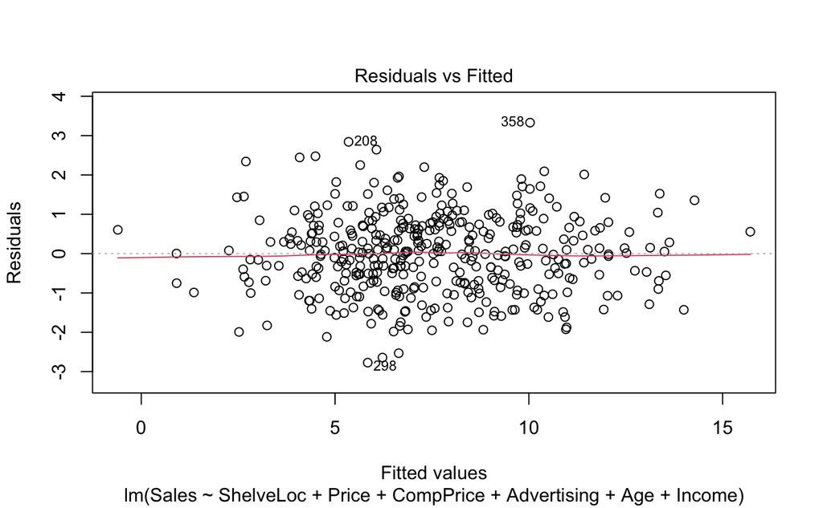

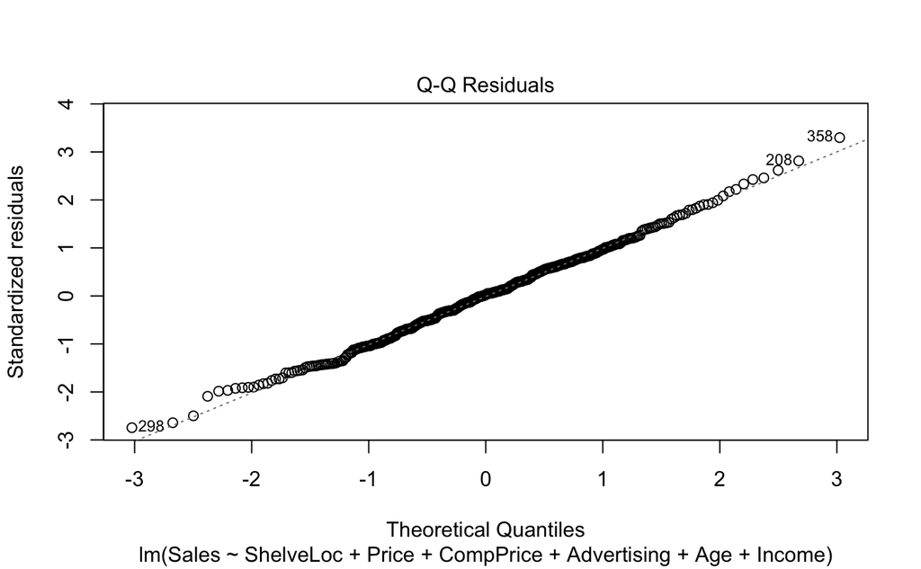

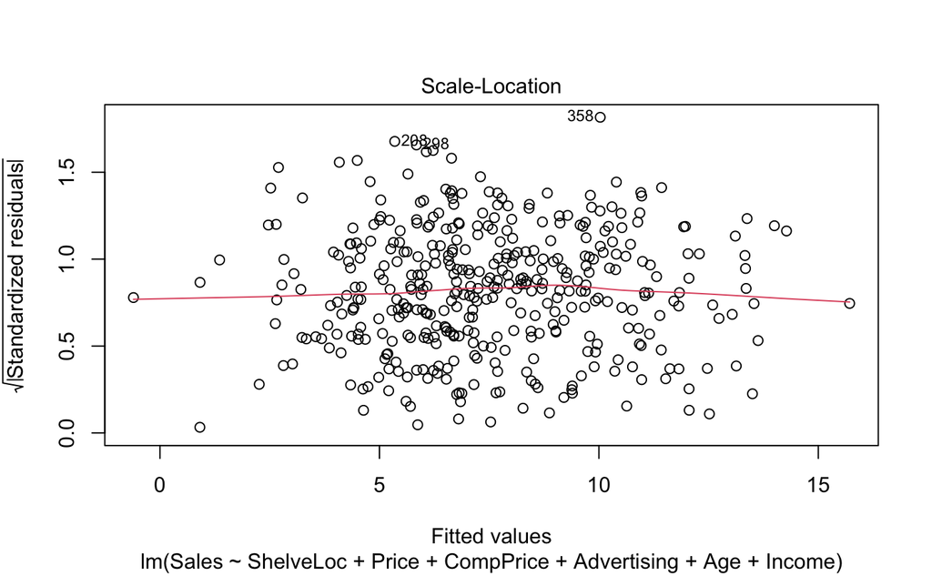

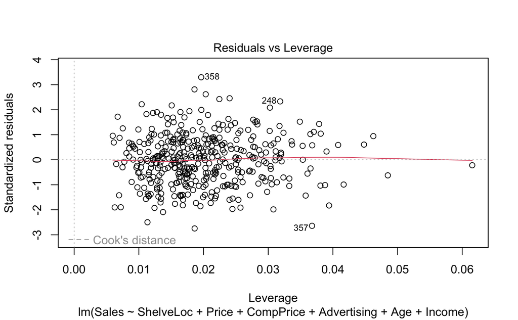

```r
plot(forward_model)
```

```r
str(Carseats)
```

```
'data.frame':   400 obs. of  11 variables:
 $ Sales      : num  9.5 11.22 10.06 7.4 4.15 ...
 $ CompPrice  : num  138 111 113 117 141 124 115 136 132 132 ...
 $ Income     : num  73 48 35 100 64 113 105 81 110 113 ...
 $ Advertising: num  11 16 10 4 3 13 0 15 0 0 ...
 $ Population : num  276 260 269 466 340 501 45 425 108 131 ...
 $ Price      : num  120 83 80 97 128 72 108 120 124 124 ...
 $ ShelveLoc  : Factor w/ 3 levels "Bad","Good","Medium": 1 2 3 3 1 1 3 2 3 3 ...
 $ Age        : num  42 65 59 55 38 78 71 67 76 76 ...
 $ Education  : num  17 10 12 14 13 16 15 10 10 17 ...
 $ Urban      : Factor w/ 2 levels "No","Yes": 2 2 2 2 2 1 2 2 1 1 ...
 $ US         : Factor w/ 2 levels "No","Yes": 2 2 2 2 1 2 1 2 1 2 ...
```

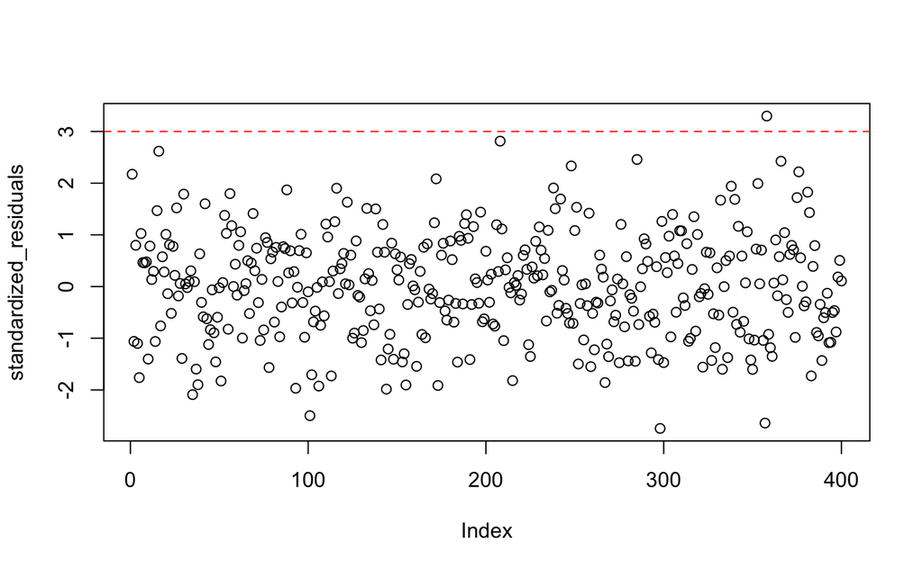

```r
standardized_residuals <- rstandard(forward_model)
plot(standardized_residuals)
abline(h = c(-3, 3), col = "red", lty = 2)
```

```r
outliers <- which(standardized_residuals < -3 | standardized_residuals > 3)
outliers
```

```
358
358
```

```r
length(outliers)
```

```
[1] 1
```

## Question 21

```r
library(ISLR)

data(College)
head(College)
```

|  | Private | Apps | Accept | Enroll | Top10perc | Top25perc | F.Undergrad | P.Undergrad | Outstate | Room.Board | Books | Personal | PhD | Terminal | S.F.Ratio | perc.alumni | Expend | Grad.Rate |
| --- | --- | --- | --- | --- | --- | --- | --- | --- | --- | --- | --- | --- | --- | --- | --- | --- | --- | --- |
| Abilene Christian University | Yes | 1660 | 1232 | 721 | 23 | 52 | 2885 | 537 | 7440 | 3300 | 450 | 2200 | 70 | 78 | 18.1 | 12 | 7041 | 60 |
| Adelphi University | Yes | 2186 | 1924 | 512 | 16 | 29 | 2683 | 1227 | 12280 | 6450 | 750 | 1500 | 29 | 30 | 12.2 | 16 | 10527 | 56 |
| Adrian College | Yes | 1428 | 1097 | 336 | 22 | 50 | 1036 | 99 | 11250 | 3750 | 400 | 1165 | 53 | 66 | 12.9 | 30 | 8735 | 54 |
| Agnes Scott College | Yes | 417 | 349 | 137 | 60 | 89 | 510 | 63 | 12960 | 5450 | 450 | 875 | 92 | 97 | 7.7 | 37 | 19016 | 59 |
| Alaska Pacific University | Yes | 193 | 146 | 55 | 16 | 44 | 249 | 869 | 7560 | 4120 | 800 | 1500 | 76 | 72 | 11.9 | 2 | 10922 | 15 |
| Albertson College | Yes | 587 | 479 | 158 | 38 | 62 | 678 | 41 | 13500 | 3335 | 500 | 675 | 67 | 73 | 9.4 | 11 | 9727 | 55 |

```r
str(College)
```

```
'data.frame':   777 obs. of  18 variables:
 $ Private    : Factor w/ 2 levels "No","Yes": 2 2 2 2 2 2 2 2 2 2 ...
 $ Apps       : num  1660 2186 1428 417 193 ...
 $ Accept     : num  1232 1924 1097 349 146 ...
 $ Enroll     : num  721 512 336 137 55 158 103 489 227 172 ...
 $ Top10perc  : num  23 16 22 60 16 38 17 37 30 21 ...
 $ Top25perc  : num  52 29 50 89 44 62 45 68 63 44 ...
 $ F.Undergrad: num  2885 2683 1036 510 249 ...
 $ P.Undergrad: num  537 1227 99 63 869 ...
 $ Outstate   : num  7440 12280 11250 12960 7560 ...
 $ Room.Board : num  3300 6450 3750 5450 4120 ...
 $ Books      : num  450 750 400 450 800 500 500 450 300 660 ...
 $ Personal   : num  2200 1500 1165 875 1500 ...
 $ PhD        : num  70 29 53 92 76 67 90 89 79 40 ...
 $ Terminal   : num  78 30 66 97 72 73 93 100 84 41 ...
 $ S.F.Ratio  : num  18.1 12.2 12.9 7.7 11.9 9.4 11.5 13.7 11.3 11.5 ...
 $ perc.alumni: num  12 16 30 37 2 11 26 37 23 15 ...
 $ Expend     : num  7041 10527 8735 19016 10922 ...
 $ Grad.Rate  : num  60 56 54 59 15 55 63 73 80 52 ...
```

```r
M1 <- lm(Apps ~ Accept * Private, data = College)

M2 <- lm(Apps ~ Accept + Private, data = College)

anova(M2, M1)
```

```
Analysis of Variance Table

Model 1: Apps ~ Accept + Private
Model 2: Apps ~ Accept * Private
  Res.Df        RSS Df Sum of Sq      F   Pr(>F)
1    774 1273430392
2    773 1262057689  1  11372703 6.9657 0.008476 **
---
Signif. codes:  0 ‘***’ 0.001 ‘**’ 0.01 ‘*’ 0.05 ‘.’ 0.1 ‘ ’ 1
```